# Measles cases across the world

Author

Carson Neubert, Ben Parker, Minh Ho-Hoang

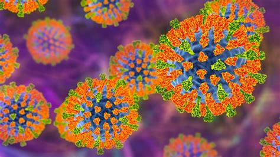

## The Measles Paradox

Measles is one of the most contagious diseases known and one of the most preventable: a two-dose vaccine costs roughly a dollar and offers near-lifetime protection. Even so, the past several years have seen a global resurgence. Routine immunization slipped during the COVID-19 pandemic, conflict and displacement disrupted vaccination campaigns in several regions, and outbreaks have re-emerged in countries that had previously eliminated the disease — raising concern that hard-won progress toward elimination is being lost.

This report combines three datasets — provisional WHO case reports, scraped historical climate data, and country-level economic and demographic indicators — to ask where measles is concentrated and which country-level conditions are most associated with its burden. We organize the analysis around two questions: how climate and geography relate to measles rates, and whether measles prevalence tracks economic and demographic differences between countries. We close with a regression model and discuss what the combined evidence suggests for global measles control.

## Data Context

#### World Health Organization (WHO)

We are exploring measles and rubella cases across the world. The data was collected and [published](https://immunizationdata.who.int/global?topic=Provisional-measles-and-rubella-data&location=) through the World Health Organization (WHO) portal, but for ease of access, scripts to access the data were provided by [tidytuesday](https://github.com/rfordatascience/tidytuesday/blob/main/data/2025/2025-06-24/readme.md).

WHO has published monthly measles and rubella data from 193 countries from June 2012 to 2025. The data is provisional and is early case reports by WHO member countries collected using each countries national surveillance systems. The data contains several types of case confirmations (suspected, clinical, epidemiologically linked, and lab confirmed) as well as population count data in the yearly data set. The data was collected to monitor measles and rubella cases worldwide in order to support public health decision making and vaccination strategies.

```r
#needed libraries
library(tidyverse)
library(gt)
library(httr)
library(tidyjson)
library(jsonlite)
library(rvest)
library(here)
library(broom)
library(ggridges)
library(scales)
library(nlme)
library(broom.mixed)
library(emmeans)

# reading in from github
cases_month <- readr::read_csv('https://raw.githubusercontent.com/rfordatascience/tidytuesday/main/data/2025/2025-06-24/cases_month.csv')
cases_year <- readr::read_csv('https://raw.githubusercontent.com/rfordatascience/tidytuesday/main/data/2025/2025-06-24/cases_year.csv')

# need to do some cleaning for the webscraping process
cases_month2 <- cases_month |>
  mutate(month_abb = recode_values(month,
                        1 ~ "Jan",
                        2 ~ "Feb",
                        3 ~ "Mar",
                        4 ~ "Apr",
                        5 ~ "May",
                        6 ~ "Jun",
                        7 ~ "Jul",
                        8 ~ "Aug",
                        9 ~ "Sep",
                        10 ~ "Oct",
                        11 ~ "Nov",
                        12 ~ "Dec"),
      country_scrape = str_to_lower(country),
      country_scrape = str_replace_all(country_scrape, " ", "-"))
```

#### Weather and Climate Data

To investigate the relationship between seasonal patterns and measles cases, we’ve web scraped data provided by [WeatherandClimate](https://weatherandclimate.com/). WeatherAndClimate is an online climate zone and data finder for 80,000+ locations in the world based on Köppen climate classification. WeatherAndClimate does not disclose the exact source or data collection method. They provide historical records dating to 1980, but we will scrape mean monthly temperature and precipitation data across this time period. The data was collected to monitor Earth’s climate systems which have broad implications on socio-economic conditions.

```r
country_vec <- c(unique(cases_month2$country_scrape))

grab_weather <- function(country) {
   base_url <- "https://weatherandclimate.com/"
   climate_url <- str_c(base_url,country)

   result <- tryCatch({
       read_html(climate_url)
     }, error = function(e) {
       message("Failed for ", country, e$message)
       NULL
     })

   if (is.null(result)) {
     return(NULL)
   } else {
     result |>
       html_element(".tb6") |>
       html_table() |>
       pivot_longer(col = Jan:Dec, names_to = "month", values_to = "stat") |>
       filter(Month %in% c("Average precipitation mm (inches)", "Daily mean °C (°F)")) |>
       select(!Year) |>
       pivot_wider(names_from = "Month", values_from = "stat") |>
       rename(mean_temp = 2,
          mean_precip = 3) |>
       mutate(mean_temp = as.numeric(str_extract(mean_temp, "(?<=\\()[0-9.]+")),
             mean_precip = as.numeric(str_extract(mean_precip, "(?<=\\()[0-9.]+")),
             country = country) #got the regex case from AI looks for values in the ()

   }
 }

 scraped_weather <- map(.x = country_vec, .f = grab_weather) |>
   bind_rows(.id = "id")


# save for loading more than once
# write.csv(scraped_weather, "./site/data/weather-scrape.csv")
```

#### Country Demographic Dataset

The Country Demographic Dataset is taken from API Ninja’s Country API, which provides geographic, demographic, and economic statistics about every country in the world. API Ninjas publishes the data through its Country API, but their documentation does not specify the original primary collector of each statistic. Variables in the dataset include: population, GPD, surface area, unemployment, homicide rate, infant mortality, fertility, and more.

The observational unit in this dataset is a country, where each row represents one country and each column represents a country-level statistic. The exact dates at which country statistics were originally collected are not stated in the API documentation. Thus, the data used in this analysis represent the values returned by the API at the time we originally accessed it.

The data was collected for this project by sending requests to the API Ninjas Country API and retrieving the given JSON objects. Each of these JSON objects contains country level statistics, which were then put into a dataset where each country became one observation and each statistic became a variable/column.

The data was collected because it allows us to make comparisons between a country’s economic, demographic, or geographic characteristics and how prevalent measles is in those countries. We hypothesize that such factors are associated with changes in measles cases and have retrieved them from this API to assess our hypothesis.

```r
country_names <- unique(cases_year$country)

api_key <- "hmz9wf1cpAko2WM4Fz3oPInaZIt44Uf9uh3VFfxD"

base_url <- "https://api.api-ninjas.com/v1/country"

get_country_demo <- function(country_name){
  GET(url = base_url,
      add_headers('X-API-Key' = api_key),
      query = list(name = country_name)) |>
  content("text", encoding = "utf-8") |>
  fromJSON() |>
  as.data.frame()
}

country_demographic <- map_dfr(country_names, get_country_demo)
# after the join... 2756 of the 22,780 datapoints don't have temp or precip data
# 19 of the 173 countries failed in the iteration
# cleaning script to not need api calls
# country_demographic_clean <- country_demographic |>
#   unnest(currency, names_sep = "_")
#
# write_csv(country_demographic_clean, "data/country_demographic.csv")
```

#### Final Dataset

```r
api_load <- read.csv("./data/country_demographic.csv")
# load csv climate data
scraped_data <- read.csv(here("data", "weather-scrape.csv"))

cases_month3 <- left_join(cases_month2, scraped_data, by = c("month_abb" = "month",  "country_scrape" = "country" ),
                          relationship = "many-to-many")
meta_data <- left_join(cases_month3,
                       api_load,
                       by = c("country" = "name"),
                       relationship = "many-to-many")
```

Our final dataset is the three previous datasets joined together. The web-scraped data was joined onto the measles case data by month and by country. The API fetched data was joined onto the result of the previous join by country. Thus, we have a single dataset containing statistics on measles cases, countries, and environmental factors.

## Research Questions

### Climate, Geography and Measles Rates

Our first analysis aims to isolate trends in measles rates across climatic factors, natural resources and geography. We aim to answer the following question:

- **How do climate and geography relate to measles and rubella cases across the world?**

And more specifically:

- Are there seasonal patterns in measles outbreaks across different regions?
- How are climate, natural resources and emissions related to measles/rubella cases?
- How are total measles cases spatially distributed throughout the world’s regions?

To better understand the relationship between climate and measles/rubella cases, we will explore monthly mean lab confirmed measles/rubella cases in the northern and southern hemisphere. We will ignore changes across years, and focus on monthly variation. We will compare India and Indonesia, who are both in the [top 10 countries](https://www.cdc.gov/global-measles-vaccination/data-research/global-measles-outbreaks/index.html) with the worst measles outbreaks as of 2023.

```r
# Use of unmodified column, custom function
monthly_sums <- function(df, group, countries) {
  if (is.data.frame(df)) {
    df |>
      filter(country %in% c(countries)) |>
      group_by({{group}}, country) |>
      summarize(
                `Mean Measles Cases` = mean(measles_lab_confirmed, na.rm = TRUE),
                `Mean Rubella Cases` = mean(rubella_lab_confirmed, na.rm = TRUE),
                .groups = "drop") |>
      mutate(month_abb = factor(month_abb, levels = month.abb)) |>
      arrange(month_abb) |>
      pivot_longer(cols = c(`Mean Measles Cases`, `Mean Rubella Cases`),
                   names_to =  "Statistic",
                   values_to = "value") |>
      pivot_wider(names_from = month_abb,
                  values_from = value) |>
      group_by(country) |>
      gt() |>
      tab_style(
        style = cell_text(weight = "bold"),
        locations = list(cells_column_labels(), cells_row_groups())) |>
      tab_header(
        title = md("Mean Lab Confirmed Measles and Rubella Cases Per Month")) |>
      tab_source_note(
        source_note = md("*Table 1: Mean monthly lab-confirmed measles and rubella cases over the course of the study (2012-2025).*")) |>
      fmt_number(
        columns  = where(is.numeric),
        decimals = 1) |>
      data_color(
        columns = everything(),
        palette = "Oranges"
       )
  } else {
  stop('Must input a dataframe')
  }
}

monthly_sums(df = meta_data,
             group = month_abb,
            countries = c("Indonesia" , "India"))
```

Mean Lab Confirmed Measles and Rubella Cases Per Month

| Statistic | Jan | Feb | Mar | Apr | May | Jun | Jul | Aug | Sep | Oct | Nov | Dec |
| --- | --- | --- | --- | --- | --- | --- | --- | --- | --- | --- | --- | --- |
| India |  |  |  |  |  |  |  |  |  |  |  |  |
| Mean Measles Cases | 790.8 | 824.2 | 993.8 | 792.0 | 554.4 | 325.1 | 268.5 | 255.0 | 290.7 | 362.3 | 576.4 | 750.5 |
| Mean Rubella Cases | 102.2 | 139.9 | 145.5 | 131.5 | 88.4 | 87.1 | 98.3 | 89.5 | 114.0 | 111.5 | 131.8 | 129.8 |
| Indonesia |  |  |  |  |  |  |  |  |  |  |  |  |
| Mean Measles Cases | 201.2 | 189.1 | 205.8 | 149.4 | 125.8 | 87.1 | 123.2 | 132.3 | 143.7 | 116.3 | 111.1 | 63.7 |
| Mean Rubella Cases | 76.5 | 72.8 | 71.1 | 59.2 | 48.6 | 28.8 | 20.8 | 19.7 | 26.8 | 36.9 | 28.5 | 18.2 |

*Table 1: Mean monthly lab-confirmed measles and rubella cases over the course of the study (2012-2025).*

From our analysis we see a strong relationship between month and measles/rubella cases. This confirms the long held notion of a northern hemisphere “flu season” during the winter. The relationship in Indonesia is more subtle and may be indicative of their tropical climate.

Next, we investigate how climate, natural resources and emissions are related to measles/rubella cases.

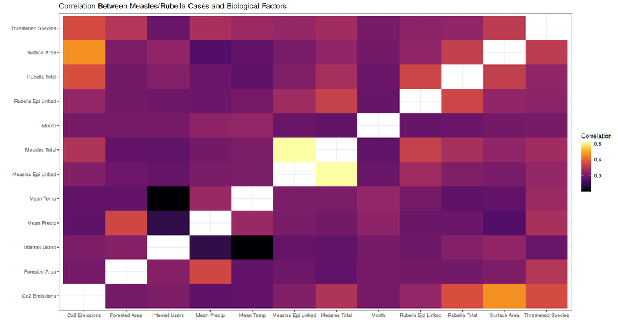

Figure 1: Correlation matrix showing the relationship between climate, natural resources and emissions data and measles/rubella cases.

```r
library(corrr)
make_titles <- function(x){
  # expects a character or factor as an input
  stopifnot(is.character(x) | is.factor(x))

  # remove the units at the end of the name
  str_remove(x, pattern = "(g|mm)$") |>
  # replace all _ with spaces
  str_replace_all(pattern = "_", replacement = " ") |>
  # remove extra whitespace on left
  str_trim(side = "both") |>
  # convert the first letter of each word to upper case
  str_to_title()
}

meta_data |>
  select(month, measles_total, measles_epi_linked, rubella_total,
         rubella_epi_linked, mean_temp, mean_precip, surface_area,
         forested_area, co2_emissions, threatened_species, internet_users) |>
  correlate(method = "pearson",
            use = "pairwise.complete.obs") |>
  rename(term1 = term) |>
  pivot_longer(cols = -term1,
               names_to = "term2",
               values_to = "correlation") |>
  filter(term1 != term2) |>
  mutate(
    across(.cols = c(term1, term2),
           .fns = ~ make_titles(.x)
           )
    ) |>
  ggplot(mapping = aes(x = term1,
                       y = term2,
                       fill = correlation)) +
  geom_tile() +
  labs(x = "",
       y = "",
       title = "Correlation Between Measles/Rubella Cases and Biological Factors",
       fill = "Correlation"
       ) +
  theme_bw() +
  scale_fill_viridis_c(option = "B")
```

When comparing climate and natural resources, we see expected results such as a positive correlation between mean precipitation and forested area. We also see a positive correlation between CO₂ emissions and measles/rubella cases (Figure 1) — a surprising finding that likely reflects population and industrial scale rather than a direct biological link.

Finally, we investigate spatial differences in measles cases from last year and compare the distributions of total measles cases across world regions (Figure 2).

```r
regions_df <- cases_year |>
  mutate(region = recode_values(region,
                    "EMRO" ~ "Eastern Mediterranean",
                    "AFRO" ~ "Africa",
                    "EURO" ~ "Europe",
                    "SEARO" ~ "South-East Asia",
                    "AMRO" ~ "Americas",
                    "WPRO" ~ "Western Pacific"))

region_burden <- function(region_name) {
  regions_df |>
    filter(year == 2025, region == region_name) |>
    mutate(measles_total = as.numeric(measles_total)) |>
    summarize(
      region = region_name,
      total_cases = sum(measles_total, na.rm = TRUE)
    )
}

regions <- unique(regions_df$region)

map(regions, region_burden) |>
  bind_rows(.id="id") |>
  mutate(pct_global = round(total_cases / sum(total_cases) * 100, 1)) |>
  arrange(desc(total_cases)) |>
  select(!id) |>
  gt() |>
  tab_header(
    title    = md("**Regional Measles Burden**"),
    subtitle = "2025 Contribution to Global Total"
  ) |>
  cols_label(
    region      = "Region",
    total_cases = "Total Cases",
    pct_global  = "% of Global Total"
  ) |>
  fmt_number(columns = total_cases, decimals = 0) |>
  fmt_number(
    columns  = pct_global,
    decimals = 1,
    pattern  = "{x}%"
    ) |>
  tab_style(
    style     = cell_text(weight = "bold"),
    locations = cells_column_labels()
  ) |>
  tab_source_note(
    source_note = md("*Table 2: Total measles cases and share of global burden by WHO region, 2025.*")
  ) |>
  data_color(
        columns = everything(),
        palette = "Oranges"
       )
```

**Regional Measles Burden**

2025 Contribution to Global Total

| Region | Total Cases | % of Global Total |
| --- | --- | --- |
| Eastern Mediterranean | 31,052 | 34.9% |
| Africa | 18,832 | 21.2% |
| Europe | 18,551 | 20.9% |
| South-East Asia | 10,856 | 12.2% |
| Americas | 5,340 | 6.0% |
| Western Pacific | 4,222 | 4.8% |

*Table 2: Total measles cases and share of global burden by WHO region, 2025.*

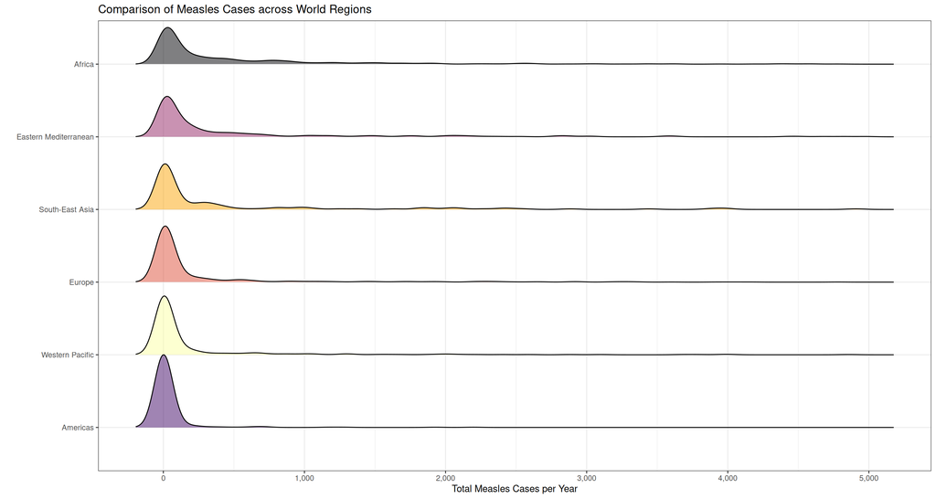

Figure 2: Comparison of the distribution of measles cases per year across world regions.

```r
regions_df |>
  filter(measles_total <= 5000) |>
  ggplot(aes(x = measles_total, y = fct_reorder(region, measles_total,
                                                .desc = FALSE), )) +
  geom_density_ridges(aes(fill = region),
                      alpha = 0.5, scale = 1,
                      show.legend = FALSE) +
  labs(x = "Total Measles Cases per Year",
       y = "",
       title = "Comparison of Measles Cases across World Regions"
       ) +
  theme(legend.position = "none") +
  scale_x_continuous(labels = label_comma()) +
  theme_bw() +
  scale_fill_viridis_d(option = "B")
```

The density ridge plot spans the full dataset (2012-2025) and so reflects long-term regional measles rates, which differ from the 2025 snapshot in Table 2. Notably, the regions with the largest 2025 share are not always those with the heaviest long-run distributions — a shift that points to outbreak dynamics a deeper temporal analysis could unpack.

### Measles Cases and Economics

Having examined environmental factors, we now turn to economic and demographic conditions and ask whether they help explain country-level differences in measles prevalence. Specifically, we seek to answer:

- **Is measles prevalence associated with country-level economic and demographic characteristics?**

More specifically:

- Does the impact of measles vary across countries?
- Is the prevalence of measles associated with the economic prosperity of a country?

First, we will examine which countries have the highest and lowest number of measles cases per year. We chose to scale total cases per 100,000 people to provide better estimates on the prevalence of measles in a countries population.

```r
country_measles <- meta_data |>
  group_by(country) |>
  summarize(avg_yearly_measles_cases = mean(measles_total, na.rm = TRUE),
            avg_population = mean(population, na.rm = TRUE)) |>
  mutate(cases_per_100k = (avg_yearly_measles_cases / avg_population) * 100000) |>
  filter(!is.na(cases_per_100k),
         is.finite(cases_per_100k),
         cases_per_100k != 0)

rank_type <- c("Highest", "Lowest")

get_rank <- function(rank_type) {
  if (rank_type == "Highest") {
    country_measles |>
      slice_max(cases_per_100k, n = 5, with_ties = FALSE) %>%
      mutate(group = "5 Highest Cases per 100,000")
  } else {
    country_measles |>
      slice_min(cases_per_100k, n = 5, with_ties = FALSE) %>%
      mutate(group = "5 Lowest Cases per 100,000")
  }
}

table_data <- map_dfr(rank_type, get_rank)

table_data |>
  gt(groupname_col = "group") |>
  cols_label(country = "Country",
             avg_yearly_measles_cases = "Avg. Yearly Measles Cases",
             avg_population = "Avg. Population",
             cases_per_100k = "Cases per 100,000 People") |>
  fmt_number(columns = c(avg_yearly_measles_cases,
                         avg_population,
                         cases_per_100k),
             decimals = 2) |>
  tab_header(title = "Countries with the Highest and Lowest Measles Cases per 100,000 People",
             subtitle = "Based on average yearly measles cases and average population") |>
  tab_style(style = cell_text(weight = "bold"),
            locations = cells_row_groups()) |>
  tab_style(style = cell_text(weight = "bold"),
            locations = cells_title()) |>
  tab_style(style = cell_text(weight = "bold"),
            locations = cells_column_labels()) |>
  tab_source_note(
                  source_note = md("*Table 3: Countries are ranked by average yearly measles cases per 100,000 people. The table compares the five countries with the highest rates and the five countries with the lowest rates.*")
)|>
  data_color(
        columns = everything(),
        palette = "Oranges"
       )
```

Countries with the Highest and Lowest Measles Cases per 100,000 People

Based on average yearly measles cases and average population

| Country | Avg. Yearly Measles Cases | Avg. Population | Cases per 100,000 People |
| --- | --- | --- | --- |
| 5 Highest Cases per 100,000 |  |  |  |
| Tonga | 11.33 | 106.00 | 10,691.82 |
| Mongolia | 340.72 | 3,278.00 | 10,394.12 |
| Solomon Islands | 40.58 | 687.00 | 5,907.33 |
| Kyrgyzstan | 373.75 | 6,524.00 | 5,728.90 |
| Madagascar | 1,403.40 | 27,691.00 | 5,068.06 |
| 5 Lowest Cases per 100,000 |  |  |  |
| Guatemala | 0.01 | 17,916.00 | 0.05 |
| Cuba | 0.01 | 11,327.00 | 0.06 |
| Ecuador | 0.02 | 17,643.00 | 0.09 |
| Paraguay | 0.01 | 7,132.00 | 0.12 |
| Peru | 0.44 | 32,972.00 | 1.32 |

*Table 3: Countries are ranked by average yearly measles cases per 100,000 people. The table compares the five countries with the highest rates and the five countries with the lowest rates.*

We then examined the relationship between a country’s economic standing and its measles cases. Since graphing all 200 countries would produce a cluttered visualization, we focused on the five richest and five poorest countries and compared how their measles cases changed over time. These countries were identified using a Wikipedia page ranking countries by GDP (PPP) per capita.

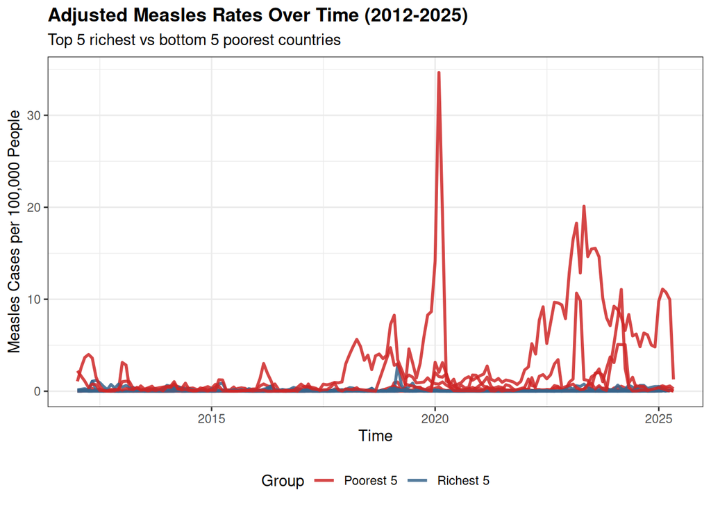

Figure 3: Line plot of measles cases over time comparing five richest countries and five poorest countries from Wikipedia ranking.

```r
richest_5 <- c("Singapore", "Ireland", "Luxembourg", "Norway", "Qatar")
poorest_5 <- c("Burundi", "Central African Republic", "South Sudan", "Yemen", "Mozambique")

timeseries_df <- meta_data |>
  mutate(
    date = make_date(year, month, 1),
  measles_per_100k = (measles_total / (population * 1000)) * 100000  ) |>
  filter(country %in% c(richest_5, poorest_5)) |>
  mutate(
    wealth_group = case_when(
      country %in% richest_5 ~ "Richest 5",
      country %in% poorest_5 ~ "Poorest 5"
    )
  )

timeseries_df |>
  ggplot(aes(x = date, y = measles_per_100k, group = country, color = wealth_group)) +
  geom_line(linewidth = 1, alpha = 0.85) +
  scale_color_manual(
    values = c("Richest 5" = "steelblue4", "Poorest 5" = "firebrick3")
  ) +
  labs(
    title = "Adjusted Measles Rates Over Time (2012-2025)",
    subtitle = "Top 5 richest vs bottom 5 poorest countries",
    x = "Time",
    y = "Measles Cases per 100,000 People",
    color = "Group") +
  theme_bw() +
  theme(
    plot.title = element_text(face = "bold"),
    legend.position = "bottom")
```

From 2012 to 2025, the poorest five countries experienced higher measles case counts than the richest five countries. While measles cases in the richest group remained close to zero in the past 13 years, the poorest group showed repeated outbreak spikes, with large increases in more recent times. This suggests a strong association between GDP and measles cases.

While the time series plot compares measles rates between the richest and poorest country groups, it does not show the size of the economic difference between those groups. The following table will take a deeper dive into this discrepancy.

```r
gdppc_for_countries <- function(data, rich_countries, poor_countries) {
  data |>
    mutate(
      gdp_per_capita = (gdp / population) * 1000,
      group = case_when(
        country %in% rich_countries ~ "Richest 5",
        country %in% poor_countries ~ "Poorest 5")) |>
    filter(country %in% c(rich_countries, poor_countries)) |>
    group_by(group, country) |>
    arrange(desc(year), .by_group = TRUE) |>
    summarize(
      gdp_per_capita_usd = first(gdp_per_capita),
      .groups = "drop") |>
    arrange(group, desc(gdp_per_capita_usd)) |>
    gt(groupname_col = "group") |>
    fmt_currency(
      columns = gdp_per_capita_usd,
      currency = "USD",
      decimals = 0) |>
    cols_label(
      country = "Country",
      gdp_per_capita_usd = "GDP per Capita (USD)") |>
    tab_style(style = cell_text(weight = "bold"),
            locations = cells_title()) |>
    tab_style(style = cell_text(weight = "bold"),
            locations = cells_column_labels()) |>
    tab_style(style = cell_text(weight = "bold"),
            locations = cells_row_groups()) |>
    tab_header(
      title = md("**GDP per Capita of Selected Richest and Poorest Countries**"),
      subtitle = "Countries grouped using GDP per capita rankings") |>
    tab_source_note(
                    source_note = md("*Table 4: GDP per capita was calculated as GDP divided by population.
      GDP expressed in millions of USD, and population in thousands.*")) |>
    tab_options(table.width = pct(65))|>
  data_color(
        columns = everything(),
        palette = "Oranges"
       )
}

gdppc_for_countries(meta_data, richest_5, poorest_5)
```

**GDP per Capita of Selected Richest and Poorest Countries**

Countries grouped using GDP per capita rankings

| Country | GDP per Capita (USD) |
| --- | --- |
| Poorest 5 |  |
| Yemen | $894 |
| South Sudan | $733 |
| Mozambique | $471 |
| Central African Republic | $464 |
| Burundi | $276 |
| Richest 5 |  |
| Luxembourg | $113,291 |
| Norway | $80,090 |
| Ireland | $77,496 |
| Qatar | $66,422 |
| Singapore | $61,729 |

*Table 4: GDP per capita was calculated as GDP divided by population. GDP expressed in millions of USD, and population in thousands.*

It is important to note that because the countries were grouped using GDP per capita rankings, an economic gap between the two groups is expected. However, the size of this gap is not immediately visible from the time series plot alone. Based on the table, the selected richest countries have approximately 150 times higher GDP per capita than the selected poorest countries, highlighting the large economic difference between the groups.

Now, we will examine the relationship between GDP per capita and measles cases by country. Because our GDP data is taken at a single time for each country, we averaged measles cases per country, per year and plotted the average number of annual cases vs. GPD per capita. A Hexbin plot was also used as opposed to a scatterplot to better visualize the density of countries in certain GDP/case ratios.

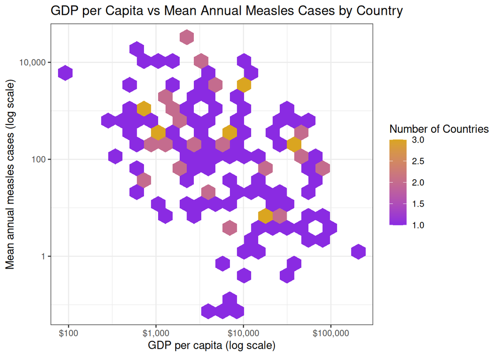

Figure 4. GDP per Capita vs Mean Annual Measles Cases by Country.

```r
library(scales)

meta_data |>
  group_by(country, year) |>
  summarise(annual_measles = sum(measles_total, na.rm=TRUE),
            gdp_per_capita = first(gdp_per_capita),
            region = first(region.x),
            .groups = "drop") |>
  group_by(country) |>
  summarise(mean_annual_measles = mean(annual_measles),
            gdp_per_capita = first(gdp_per_capita),
            region = first(region),
            .grpups = "drop") |>
  ggplot(aes(x = gdp_per_capita, y = mean_annual_measles)) +
  geom_hex(bins = 20) +
  scale_x_log10(labels = dollar_format()) +
  scale_y_log10(labels = comma_format()) +
  scale_fill_gradient(low = "blueviolet",
                      high = "goldenrod") +
  labs(
    title = "GDP per Capita vs Mean Annual Measles Cases by Country",
    x = "GDP per capita (log scale)",
    y = "Mean annual measles cases (log scale)",
    fill = "Number of Countries",
    alt = paste(
      "Hexbin plot of countries comparing GDP per capita and mean annual measles
      cases.",
      "Both axes are on log scale.",
      "Contries are concentrated along a negatively correlated line, with many
      contries having low GDP and high measles cases, while many others have low
      measles cases and high GDP."
    )
  ) +
  theme_bw()
```

Our analysis shows that as GDP per capita increases, mean annual measles cases decrease (Figure 4). Richer countries, on average, report fewer cases — a pattern consistent with better vaccination coverage, healthcare access, and surveillance, though our cross-sectional data does not distinguish between these explanations.

### Data Model

To rigorously examine the relationship between country-level characteristics and measles prevalence, we constructed a generalized least squares (GLS) linear regression model. The response variable was the measles case rate per 100,000 people, which we log-transformed to address the strong right skew typical of disease count data and to allow for a multiplicative interpretation of effects. Similarly, two explanatory variables - GDP per capita and the number of international tourists - were log-transformed to normalize their distributions and reduce the influence of extreme values. All six WHO world regions are represented in the model, using Africa (AFR) as the reference category. For clarity, the following abbreviations are used throughout: AFR = Africa, EMR = Eastern Mediterranean, EUR = Europe, SEAR = Southeast Asia, WPR = Western Pacific, and AMR = Americas. The full set of predictors includes log GDP per capita, WHO region, year, mean annual temperature, log number of tourists, and urban population percentage, along with an interaction term between log GDP per capita and region to allow the economic gradient of measles rates to vary across global contexts.

```r
meta_data <- meta_data |>
  distinct(country, year, month, .keep_all = TRUE)

linearreg_df <- meta_data |>
  select(
    country,
    region.x,
    year,
    month,
    gdp,
    population,
    measles_total,
    mean_temp,
    urban_population,
    tourists) |>
  mutate(
    gdp_per_capita = gdp / population,
    measles_rate_100k = (measles_total / population) * 100000,
    log_gdp_per_capita = log(gdp_per_capita),
    log_measles_rate_100k = log(measles_rate_100k + 1),
    log_tourists = log(tourists + 1),
    year_month = as.integer(year * 12 + month),
    country = as.factor(country),
    region.x = relevel(as.factor(region.x), ref = "AFR")) |>
  arrange(country, year_month)

model <- gls(
  log_measles_rate_100k ~ log_gdp_per_capita * region.x + year +
    mean_temp + log_tourists + urban_population,
  data = linearreg_df,
  correlation = corAR1(form = ~ year_month | country),
  method = "ML",
  na.action = na.omit
)

model |>
  broom.mixed::tidy() |>
  mutate(
    term = recode_values(term,
                         "(Intercept)" ~ "Intercept",
                         "log_gdp_per_capita" ~ "Log GDP per Capita",
                         "year" ~ "Year",
                         "mean_temp" ~ "Mean Temperature",
                         "log_tourists" ~ "Log Number of Tourists",
                         "urban_population" ~ "Urban Population",
                         "region.xAMR" ~ "AMR",
                         "region.xEMR" ~ "EMR",
                         "region.xEUR" ~ "EUR",
                         "region.xSEAR" ~ "SEAR",
                         "region.xWPR" ~ "WPR",
                         "log_gdp_per_capita:region.xAMR" ~ "Log GDP per Capita x AMR",
                         "log_gdp_per_capita:region.xEMR" ~ "Log GDP per Capita x EMR",
                         "log_gdp_per_capita:region.xEUR" ~ "Log GDP per Capita x EUR",
                         "log_gdp_per_capita:region.xSEAR" ~ "Log GDP per Capita x SEAR",
                         "log_gdp_per_capita:region.xWPR" ~ "Log GDP per Capita x WPR"),
    order = case_when(
      term == "Intercept" ~ 1,
      term == "Log GDP per Capita" ~ 2,
      str_detect(term, "Log GDP per Capita x") ~ 3,
      term == "Year" ~ 4,
      term == "Mean Temperature" ~ 5,
      term == "Log Number of Tourists" ~ 6,
      term == "Urban Population" ~ 7,
      term %in% c("AMR", "EMR", "EUR", "SEAR", "WPR") ~ 8,
      TRUE ~ 9)) |>
  arrange(order, term) |>
  select(-order) |>
  gt() |>
  fmt_number(
    columns = c(estimate, std.error, statistic),
    decimals = 3) |>
  fmt_scientific(columns = p.value) |>
  cols_label(
    term = md("**Predictor**"),
    estimate = md("**Estimate**"),
    std.error = md("**Std. Error**"),
    statistic = md("**t-value**"),
    p.value = md("**p-value**")) |>
  tab_header(
    title = md("**Regression Model Results**"),
    subtitle = "Predicting logged measles case rate per 100,000") |>
  tab_source_note(
    source_note = md("*Table 5: Generalized least squares regression using GDP per capita, region, year, mean temperature, number of tourists, urban population, and a GDP-by-region interaction as predictors. AFR is the reference region.*")) |>
  data_color(
    columns = everything(),
    palette = "Oranges")
```

**Regression Model Results**

Predicting logged measles case rate per 100,000

| **Predictor** | **Estimate** | **Std. Error** | **t-value** | **p-value** |
| --- | --- | --- | --- | --- |
| Intercept | −187.196 | 24.766 | −7.559 | 4.27 × 10<sup>−14</sup> |
| Log GDP per Capita | −0.394 | 0.132 | −2.974 | 2.94 × 10<sup>−3</sup> |
| Log GDP per Capita x AMR | 0.514 | 0.207 | 2.487 | 1.29 × 10<sup>−2</sup> |
| Log GDP per Capita x EMR | −0.227 | 0.160 | −1.417 | 1.57 × 10<sup>−1</sup> |
| Log GDP per Capita x EUR | 0.224 | 0.140 | 1.598 | 1.10 × 10<sup>−1</sup> |
| Log GDP per Capita x SEAR | −0.375 | 0.289 | −1.298 | 1.94 × 10<sup>−1</sup> |
| Log GDP per Capita x WPR | 0.395 | 0.168 | 2.352 | 1.87 × 10<sup>−2</sup> |
| Year | 0.094 | 0.012 | 7.637 | 2.33 × 10<sup>−14</sup> |
| Mean Temperature | 0.002 | 0.001 | 1.079 | 2.81 × 10<sup>−1</sup> |
| Log Number of Tourists | 0.252 | 0.032 | 7.814 | 5.83 × 10<sup>−15</sup> |
| Urban Population | 0.002 | 0.004 | 0.505 | 6.14 × 10<sup>−1</sup> |
| AMR | −4.164 | 0.377 | −11.041 | 3.00 × 10<sup>−28</sup> |
| EMR | 0.431 | 0.281 | 1.535 | 1.25 × 10<sup>−1</sup> |
| EUR | −1.381 | 0.267 | −5.163 | 2.45 × 10<sup>−7</sup> |
| SEAR | −0.257 | 0.354 | −0.724 | 4.69 × 10<sup>−1</sup> |
| WPR | −1.836 | 0.321 | −5.711 | 1.14 × 10<sup>−8</sup> |

*Table 5: Generalized least squares regression using GDP per capita, region, year, mean temperature, number of tourists, urban population, and a GDP-by-region interaction as predictors. AFR is the reference region.*

**Regression Model Results**

The regression results (Table 5) reveal several statistically significant predictors of logged measles case rates. Most notably, log GDP per capita in the reference region (AFR) carries a significant negative coefficient (Estimate = -0.394, p = 0.003), indicating that wealthier African countries tend to have lower measles rates - a pattern consistent with richer nations having greater capacity to fund vaccination programs, healthcare infrastructure, and disease surveillance. However, the GDP effect is not uniform across regions; two interaction terms are statistically significant, suggesting that the relationship between wealth and measles burden differs meaningfully depending on where a country is located.

The interaction between log GDP per capita and AMR is positive and significant (Estimate = 0.514, p = 0.013), indicating that the negative association between GDP and measles rates seen in Africa is substantially attenuated in the Americas. A similar pattern holds for WPR (Estimate = 0.395, p = 0.019), where the GDP slope is likewise less negative relative to AFR. This may reflect the fact that countries in these regions have already achieved high baseline vaccination coverage even at lower income levels. By contrast, the interaction terms for EMR, EUR, and SEAR are not statistically significant, though their directions vary.

Year is a significant positive predictor (Estimate = 0.094, p < 0.001), a counterintuitive finding that warrants careful interpretation. Rather than indicating a true increase in measles globally, this likely reflects improvements in disease surveillance and reporting infrastructure over time - as countries invested in better data collection, more cases were documented. A deeper analysis on a country-level basis may provide more context to this finding. The log number of international tourists is also a highly significant positive predictor (Estimate = 0.252, p < 0.001), consistent with the well-established role of international travel in facilitating the spread of infectious diseases across borders. Mean temperature and urban population percentage do not reach statistical significance in this model (p = 0.281 and p = 0.614, respectively), suggesting that climatic and urbanization factors play a lesser role once economic development, region, and travel are accounted for.

**ANOVA Model Comparison**

```r
model_no_interaction <- gls(
  log_measles_rate_100k ~ log_gdp_per_capita + region.x + year +
    mean_temp + log_tourists + urban_population,
  data = linearreg_df,
  correlation = corAR1(form = ~ year_month | country),
  method = "ML",
  na.action = na.omit
)

anova(model_no_interaction, model) |>
  as.data.frame() |>
  mutate(
    Model = c("No interaction model", "Interaction model"),
    `p-value` = ifelse(is.na(`p-value`), NA, "< .0001")) |>
  select(Model, df, AIC, BIC, L.Ratio, `p-value`) |>
  gt() |>
  tab_header(
    title = "ANOVA Model Comparison",
    subtitle = "Testing the GDP-by-region interaction") |>
  fmt_number(
    columns = c(AIC, BIC, L.Ratio),
    decimals = 2) |>
  sub_missing(
    columns = c(L.Ratio, `p-value`),
    missing_text = "") |>
  data_color(
    columns = everything(),
    palette = "Oranges") |>
  tab_source_note(
    source_note = md("*Table 6: ANOVA model comparison between the interactive and non-interactive models.*"))
```

ANOVA Model Comparison

Testing the GDP-by-region interaction

| Model | df | AIC | BIC | L.Ratio | p-value |
| --- | --- | --- | --- | --- | --- |
| No interaction model | 13 | 62,440.63 | 62,542.14 |  |  |
| Interaction model | 18 | 62,424.47 | 62,565.03 | 26.16 | < .0001 |

*Table 6: ANOVA model comparison between the interactive and non-interactive models.*

While several individual interaction terms are significant, we conducted a formal likelihood ratio test via ANOVA to determine whether the GDP-by-region interaction as a whole improves model fit beyond the simpler additive model. The interaction model (18 parameters) achieves a significantly better fit than the no-interaction model (13 parameters), with a likelihood ratio statistic of 26.16 (p < 0.0001), despite the modest increase in model complexity reflected in the AIC and BIC values (Table 6). This confirms that the relationship between GDP per capita and logged measles rates is not constant across regions - a single global slope would obscure meaningful regional heterogeneity. Accordingly, follow-up analyses within each region are warranted to characterize these differences more precisely.

```r
library(htmltools)

gdp_slopes_by_region <- emtrends(
  model,
  specs = ~ region.x,
  var = "log_gdp_per_capita",
  mode = "appx-satterthwaite")

slopes_table <- gdp_slopes_by_region |>
  as.data.frame() |>
  select(
    Region = region.x,
    `GDP Slope` = log_gdp_per_capita.trend,
    SE,
    df,
    `Lower CI` = lower.CL,
    `Upper CI` = upper.CL) |>
  gt() |>
  tab_header(
    title = "Estimated GDP Slopes by Region",
    subtitle = "Simple slopes from the GDP-by-region interaction model") |>
  fmt_number(
    columns = c(`GDP Slope`, SE, df, `Lower CI`, `Upper CI`),
    decimals = 3) |>
  data_color(
    columns = everything(),
    palette = "Oranges")|>
  tab_source_note(
    source_note = md("*Table 7: Estimated slopes, standard errors, degrees of freedom and confidence intervals for the GDP by region interaction model.*"))


pairs_table <- pairs(gdp_slopes_by_region, adjust = "tukey") |>
  as.data.frame() |>
  mutate(
    contrast = gsub(" - ", " vs. ", contrast),
    estimate = round(estimate, 3),
    SE = round(SE, 3),
    df = round(df, 0),
    t.ratio = round(t.ratio, 2),
    `p-value` = case_when(
      p.value < .0001 ~ "< .0001",
      p.value < .001 ~ "< .001",
      TRUE ~ as.character(round(p.value, 4)))) |>
  select(
    Contrast = contrast,
    Estimate = estimate,
    SE,
    df,
    `t-ratio` = t.ratio,
    `p-value`) |>
  gt() |>
  tab_header(
    title = "Tukey Pairwise Comparisons",
    subtitle = "Follow-up tests for the interaction") |>
  fmt_number(
    columns = c(Estimate, SE, df, `t-ratio`),
    decimals = 2) |>
  data_color(
    columns = everything(),
    palette = "Oranges")|>
  tab_source_note(
    source_note = md("*Table 8: Post-hoc Tukey tests to compare GDP across the world's regions.*"))



tagList(
  div(style = "display: flex; gap: 20px; align-items: flex-start;",
      div(style = "width: 45%;", slopes_table),
      div(style = "width: 55%;", pairs_table)))
```

Estimated GDP Slopes by Region

Simple slopes from the GDP-by-region interaction model

| Region | GDP Slope | SE | df | Lower CI | Upper CI |
| --- | --- | --- | --- | --- | --- |
| AFR | −0.394 | 0.132 | 1,046.487 | −0.653 | −0.134 |
| AMR | 0.120 | 0.173 | 1,060.699 | −0.220 | 0.461 |
| EMR | −0.621 | 0.128 | 1,027.356 | −0.872 | −0.370 |
| EUR | −0.169 | 0.087 | 1,062.811 | −0.340 | 0.002 |
| SEAR | −0.768 | 0.266 | 1,001.676 | −1.291 | −0.245 |
| WPR | 0.001 | 0.145 | 1,107.964 | −0.283 | 0.286 |

*Table 7: Estimated slopes, standard errors, degrees of freedom and confidence intervals for the GDP by region interaction model.*

Tukey Pairwise Comparisons

Follow-up tests for the interaction

| Contrast | Estimate | SE | df | t-ratio | p-value |
| --- | --- | --- | --- | --- | --- |
| AFR vs. AMR | −0.51 | 0.21 | 1,046.00 | −2.49 | 0.1288 |
| AFR vs. EMR | 0.23 | 0.16 | 1,010.00 | 1.42 | 0.7169 |
| AFR vs. EUR | −0.22 | 0.14 | 1,036.00 | −1.60 | 0.6001 |
| AFR vs. SEAR | 0.38 | 0.29 | 1,004.00 | 1.30 | 0.7862 |
| AFR vs. WPR | −0.40 | 0.17 | 1,062.00 | −2.35 | 0.1746 |
| AMR vs. EMR | 0.74 | 0.20 | 1,043.00 | 3.62 | 0.0041 |
| AMR vs. EUR | 0.29 | 0.19 | 1,054.00 | 1.55 | 0.6285 |
| AMR vs. SEAR | 0.89 | 0.31 | 1,016.00 | 2.84 | 0.0519 |
| AMR vs. WPR | 0.12 | 0.21 | 1,074.00 | 0.56 | 0.9933 |
| EMR vs. EUR | −0.45 | 0.14 | 1,023.00 | −3.29 | 0.0133 |
| EMR vs. SEAR | 0.15 | 0.29 | 1,000.00 | 0.51 | 0.9956 |
| EMR vs. WPR | −0.62 | 0.17 | 1,059.00 | −3.75 | 0.0025 |
| EUR vs. SEAR | 0.60 | 0.28 | 1,003.00 | 2.18 | 0.247 |
| EUR vs. WPR | −0.17 | 0.15 | 1,090.00 | −1.14 | 0.8626 |
| SEAR vs. WPR | −0.77 | 0.29 | 1,020.00 | −2.64 | 0.0895 |

*Table 8: Post-hoc Tukey tests to compare GDP across the world’s regions.*

**Estimated GDP Slopes by Region**  
Table 7 presents the simple slopes for log GDP per capita within each region, estimated from the interaction model. The pattern reveals striking regional variation. The GDP slope is negative and statistically significant in AFR (slope = -0.394, 95% CI: -0.653 to -0.134), EMR (slope = -0.621, 95% CI: -0.872 to -0.370), and SEAR (slope = -0.768, 95% CI: -1.291 to -0.245), indicating that in these regions, higher national income is reliably associated with lower measles burden. SEAR shows the steepest negative gradient, suggesting that economic development may be a particularly important driver of measles control in that region. By contrast, in AMR (slope = 0.120, 95% CI: -0.220 to 0.461), EUR (slope = -0.169, 95% CI: -0.340 to 0.002), and WPR (slope = 0.001, 95% CI: -0.283 to 0.286), the GDP slope does not differ significantly from zero. These null associations may arise because countries in these regions have largely decoupled measles control from national income - either through universal vaccination policies or regional elimination programs that operate independently of a country’s wealth level.

**Post-Hoc Tukey Pairwise Comparisons**  
To formally test which pairs of regions differ in their GDP-measles slopes, we conducted Tukey-corrected pairwise comparisons of the regional GDP slopes (Table 8). These tests identified three significant contrasts. The GDP slope for EMR differed significantly from both AMR (p = 0.004) and WPR (p = 0.003), confirming that the strong negative association between wealth and measles in the Eastern Mediterranean region stands in contrast to the near-zero or positive slopes observed in those two regions. Additionally, the EMR slope differed significantly from EUR (p = 0.013), though the EUR slope itself was marginally non-significant. Several other contrasts - including AFR vs. AMR, AMR vs. SEAR, and SEAR vs. WPR - approach but do not cross the corrected significance threshold, suggesting there may be additional regional differences that the study is underpowered to detect.

## Discussion

Taken together, these findings paint a nuanced picture of the global measles burden. Economic development is a meaningful protective factor in lower-income regions such as AFR, EMR, and SEAR, where the healthcare and public health investments that accompany rising GDP likely translate directly into improved vaccine coverage and disease control. In higher-income regions like AMR, EUR, and WPR, however, other structural factors appear to have largely supplanted income as a determinant of measles rates. The strong and consistent effects of tourism and year further underscore the importance of cross-border disease dynamics and surveillance capacity in shaping the observed distribution of measles globally.